# Climate Change Vulnerability: The impact of droughts on populations and agricultural communities in South Africa

Claire Pavelka

3/14/2020

#The Issue

##Current Effects of Drought in South Africa

> “At this stage, it would not be necessary to declare a national disaster, but provincially, in the Western Cape, the Eastern Cape, the Northern Cape and in the Limpopo area, a disaster declaration should have been done more than a year ago” Willem Symington (Agri Northern Cape)

```
November 2019 marked a critical moment for farmers and agricultural communities in South Africa. The recent widespread drought in South Africa, and in neighbouring countries like Zimbabwe, Angola and Botswana, has put pressure on rural farmers and the food security of millions. It is estimated that the lack of rainfall and water has affected around [37% of rural communities](https://www.dailymaverick.co.za/article/2019-11-13-south-africa-unprepared-for-drought-disaster-agrisa-warns-government/).
```

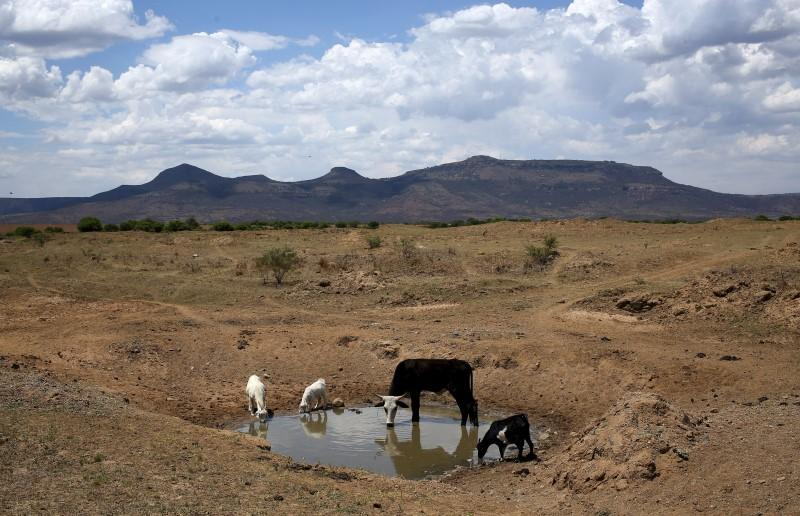

On November 12th 2019, stakeholders from various sectors of the agriculture industry met to discuss the current and future impacts of long-term [droughts on agriculture](https://www.dailymaverick.co.za/article/2019-11-13-south-africa-unprepared-for-drought-disaster-agrisa-warns-government/). Representatives from [AgriSA](https://www.agrisa.co.za/about), a federation of agricultural organizations in South Africa, were some of the most vocal attendees. They advocated for the South African government to take immediate action against the current droughts by creating a drought commission, agricultural insurance opportunities, and an early warning system.

##History of Droughts in South Africa

The 2019 drought is not the first to impact communities in South Africa. From [2012 to 2013](https://pureportal.coventry.ac.uk/en/publications/south-african-droughts-and-decadal-variability-2), a large drought affected the agriculture and livestock industries. This drought was so extensive that areas in central South Africa were classified as [‘drought stricken’](https://pureportal.coventry.ac.uk/en/publications/south-african-droughts-and-decadal-variability-2) by country agencies. Some rural communities also received financial support from various government agencies due to the health risks associated with drought. There was also a recent widespread drought from [2015 to 2016](https://www.mdpi.com/2073-4441/8/10/439) in the North West and Free State provinces in South Africa.

##Past and Current Research

In the past, researchers have made attempts to monitor droughts in South Africa. Rainfall has been the longest- monitored meteorological variable in South Africa. Studies, therefore, have utilized this long term rainfall data to [investigate droughts](https://www.mdpi.com/2073-4441/8/10/439). In many cases this research utilized the Standardised Precipitation Index (SPI) to evaluate the intensity and frequency of drought events over recent and historic time scales.

Past research has been focused on the frequency and intensity of droughts in South Africa. There has not been much research, however, on the relationship between droughts and vulnerable populations, especially in relation to agriculture. This analysis will build on previous work by investigating the relationship between droughts, vulnerable populations, and agriculture. The two main questions that will be addressed are: > 1. What is the relationship between climate change, vulnerable populations, and  
agricultural communities? > 2. How will climate change impact vulnerable populations and agricultural communities?

#Why is this important?

South Africa is situated in an area with high variability of climate, as the country is located within a [“subtropical high pressure belt”](https://pureportal.coventry.ac.uk/en/publications/south-african-droughts-and-decadal-variability-2). With the onset of climate change these shifts in the climate are predicted to become more variable and extreme. Historically, droughts are an important part of the South African climate and landscape. Short- term droughts, lasting from 3 to 12 months, usually cause small effects on agriculture and local communities. Longer drought periods can cause these impacts to [intensify](https://www.ajol.info/index.php/wsa/article/view/5057) especially if the drought persists for multiple years.

In the past, local communities were able to adapt to changing weather conditions. But, at the current rate of climate change, many communities will not be able to acclimate to the rapid and variable shifts in climate. Extreme weather events, like future droughts, are likely to become more [intense and prolonged](https://www.climatelearningplatform.org/sites/default/files/resources/Stringeretal.ES%2BP.pdf) as climate warms around the globe. In particular, the continent of Africa is one of the most vulnerable world regions to these changes. Many human populations in Africa already have developmental obstacles, such as poverty and food insecurity. These challenges will only worsen with the predicted environmental changes.

#Droughts in South Africa

##The SPI Index

[output not shown]

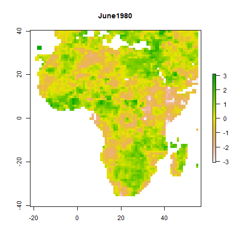